# Fall detection

Name: Guillaume De Gani

The purpose of this notebook is to study the fall detection using floor sensors and to select the right model to predict wether or not the subject fell which in the future could help elders in their daily lives.

# Initializing the Data

|  | obs | raw_feat_X1 | raw_feat_X2 | raw_feat_X3 | raw_feat_X4 | raw_feat_X5 | raw_feat_X6 | raw_feat_X7 | raw_feat_X8 | raw_feat_X9 | ... | deriv_feat_X21 | deriv_feat_X22 | deriv_feat_X23 | deriv_feat_X24 | deriv_feat_X25 | deriv_feat_X26 | deriv_feat_X27 | deriv_feat_X28 | deriv_feat_X29 | FALL |
| --- | --- | --- | --- | --- | --- | --- | --- | --- | --- | --- | --- | --- | --- | --- | --- | --- | --- | --- | --- | --- | --- |
| 0 | 0 | 0.249744 | -0.162770 | 0.223727 | 0.393904 | -0.154366 | 0.128968 | 1.090661 | 0.913849 | 0.505526 | ... | 0.121241 | 0.734862 | 0.179370 | 0.402461 | 0.638393 | 0.344236 | 0.823239 | -0.409350 | 1.425206 | 1 |
| 1 | 1 | 0.385843 | -0.660978 | -0.127798 | -0.205710 | -0.160936 | 0.111606 | 0.171391 | 2.889781 | 0.377333 | ... | -0.182778 | 0.357499 | -0.056181 | 0.840313 | 0.605672 | 0.655029 | 1.052671 | -0.177353 | 1.613721 | 1 |
| 2 | 2 | 3.344528 | -4.535931 | 0.165140 | -0.228745 | 3.203818 | 3.379462 | 1.089901 | 2.097552 | 0.877990 | ... | 0.425260 | 8.093449 | -0.684318 | 0.046744 | 3.440332 | 3.965586 | 2.916183 | 0.367674 | 3.952479 | 1 |
| 3 | 3 | 3.190676 | -2.884463 | -1.153080 | -0.698292 | 1.868221 | 2.493077 | 2.546198 | 3.817391 | 3.711000 | ... | -4.743065 | -0.774592 | -1.076903 | -0.818687 | 3.572430 | 3.409429 | 2.407953 | 1.233629 | 2.702845 | 1 |
| 4 | 4 | 2.338575 | -2.699941 | -0.069211 | -0.025849 | 1.420714 | 2.137326 | 1.097388 | 2.101987 | 1.200319 | ... | -2.766941 | 0.168817 | -1.116162 | -1.640847 | 1.527936 | 2.215856 | 2.353429 | 0.721413 | 2.933661 | 1 |

5 rows × 89 columns

As you can see above, the dataset has 87 features and the target feature "Fall". The 87 features are seperated in 3 categories each going from X1 to X29:

- `FALL` : The label of the data wich indicates wether or not the person fell
- `raw` : The raw data extracted from the sensors
- `deriv` : The derivative of the data from the sensors
- `fft` : The energy of the signals

We start by initializing the data we need for the diffent models, to do so the data is split it two stets:

- `X` : Which is the feature matrix
- `Y` : Which is the label vector

After splitting the data in two sets `X` & `Y` we can apply `train_test_split` which is a quick and easy way to split the data in a training set and a testing set to properly check the accuracy of our model. In this case we set aside `20%` of the data to test it after fitting the various models.

The data count is the following:

- `2619` instances of label 0 representing a **Not Fall**
- `202` instances of label 1 representing a **Fall**

Before starting the analyses it is important to note that the data is fairly imbalanced i.e only **7,16%** of the data represents a fall. Which means that using accuracy is unwise since the model could easily reach **93%** accuracy by labeling all data as 0. For this reason it's preferable to use `f1` score to only measure true positive and avoid these issues.

# Quick overlook of the various models

In this section different model will be tested and for each classifier a confusion matrix will be ploted which gives important information notably on the true positive rate `TPR` of the model which is the most important metrics when studying imablanced data.

Here a list of the models that were tested and compared:

- `Random Forest`
- `Support Vector Machine`
- `Naive Bayesian`
- `Decision Tree`
- `K-Nearest Neighboors`
- `AdaBoost`
- `Gradient Boosting`
- `Bagging`

The first model that is tested is Random Forest were we plot the confusion matrix which is helpfull to see how accurate the model list by checking that the diagonal as high values.

```
<sklearn.metrics._plot.confusion_matrix.ConfusionMatrixDisplay at 0x1f6b72f6400>
```

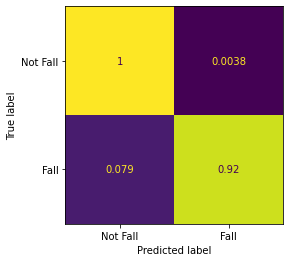

The result for the first model gives an `F1` score of **93.3%** and a precision of **95%**. These result are promissing with the amount of data that was used for the training.

The next model that was tested was a support vector machine with three different kernels:

- `rbf` : Exponential kernel
- `poly` : Second degree polynomial kernel
- `linear` : Linear kernel

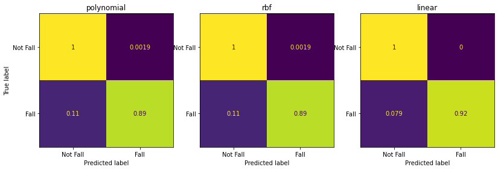

And once again all the models have fairly high `Accuracy` and `F1` score however this was done without cross validation so the sanity of the data selected migh be the reason for these high value.

The next plot represent the confusion matrix for another set of classifier once again just to do a quick sanity check and see if any of them give absurd results.

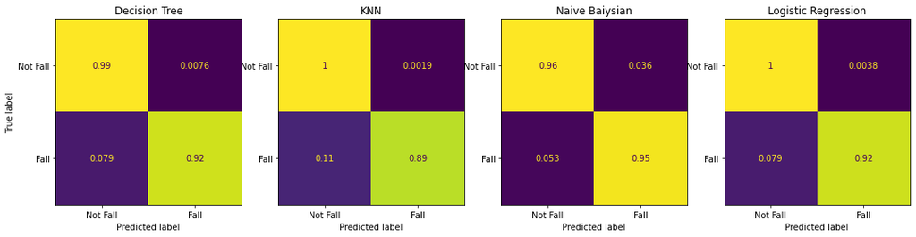

Every confusion matrix as a diagonal that is close to one which indecates that these model are fairly accurate.

# Comparing the models

After testing the diffrent model to check if any of them were giving absurd results it's important to compare them to see which model performs the best. To do so it's important to find diffrent ways to visulize the scoring parameter of the classifier tested.

**Receiver Operator Characteristic curve (ROC)**

The closer it is to **1** the better the model is at classifying the data. In this case every model as an `AUC` above `0.90` which seems very promising.

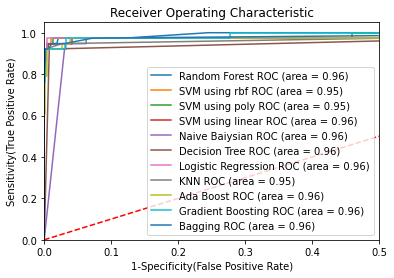

**K-Fold cross validation**

Previously the model were evaluated without using cross validation, to get better results it's best practice to measure the diffrent `metrics` by averaging on a K-Fold. The following data is optained using 10-folds.

Score table

| Classifier | Average F1 score | Accuracy of Fall detection |
| --- | --- | --- |
| Random Forest | 0.93 ± 0.03 | 0.90 |
| SVM using rbf | 0.93 ± 0.03 | 0.88 |
| SVM using poly | 0.92 ± 0.04 | 0.86 |
| SVM using linear | 0.92 ± 0.04 | 0.91 |
| Naive Baiysian | 0.78 ± 0.04 | 0.94 |
| Decision Tree | 0.88 ± 0.06 | 0.88 |
| Logistic Regression | 0.93 ± 0.03 | 0.90 |
| KNN | 0.91 ± 0.04 | 0.87 |
| Ada Boost | 0.90 ± 0.03 | 0.87 |
| Gradient Boosting | 0.91 ± 0.03 | 0.89 |
| Bagging | 0.92 ± 0.04 | 0.87 |

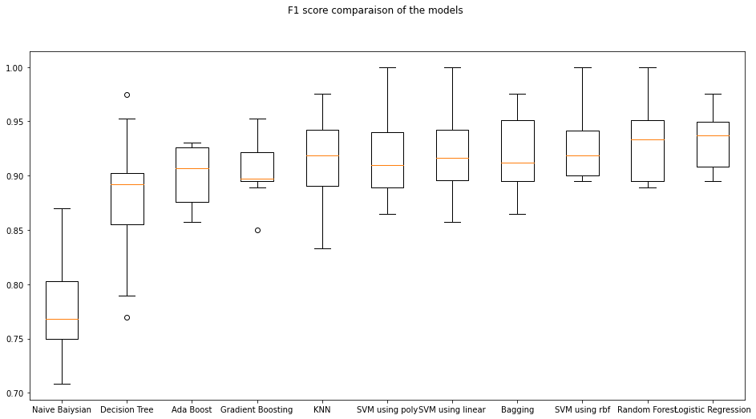

# Conclusion

The data given was fairly imbalanced towards the first label which represents the patient **not falling**. This made it challenging to find a model that was performing well overall and that wasn't missing to many **falls** which if applied in real life could be problematic.

Finally the question can be asked regarding is using transfer learning since this data was optained by using fairly young test subjects age `25` to `45` and it's supposed to be applied for seniors e.g `above 65`. It's likely that their walking patern and falling patern could differ slightly like in their speed for example. And for obvious reason getting data by asking seniors to `fall` on purpose seems highly unethical.

Another question that can be asked is the impacts of walking aids like **canes** and **walkers** on the data receveid by the floor sensors. This could be an important factor to consider since in the US `16.4%` of seniors use a cane and `11.6%` use a walker.